# PAC_2

2025-04-20

## 1 Breu anàlisi visual

A partir de les preguntes de recerca formulades, representeu visualment les variables a estudiar de manera que orientin les respostes a aquestes preguntes. És a dir, per cada pregunta de recerca, representeu un gràfic que ajudi a interpretar visualment la distribució de les variables per aquella pregunta. Escolliu el gràfic que sigui més apropiat en funció del vostre criteri. Estructureu aquesta secció en diferents subseccions, una per cada pregunta de recerca.

Llegir el fitxer de dades sleephealth.csv.

```r
library(readxl)
data <- read_excel("~/Documentos/GitHub/UOC-treballs/analisis_estadistic/pac2/sleephealth_processed.xlsx")
kable(head(data))
```

| ID | Gender | Age | Occupation | SH | SQ | PHY | Stress | BMI | BP | HR | Steps | SD | BPsyst | BPdias |
| --- | --- | --- | --- | --- | --- | --- | --- | --- | --- | --- | --- | --- | --- | --- |
| 1 | Male | 27 | Software Engineer | 6.1 | 6 | 42 | 6 | Overweight | 126/83 | 77 | 4200 | None | 126 | 83 |
| 2 | Male | 28 | Doctor | 6.2 | 6 | 60 | 8 | Normal | 125/80 | 75 | 10000 | None | 125 | 80 |
| 3 | Male | 28 | Doctor | 6.2 | 6 | 60 | 8 | Normal | 125/80 | 75 | 10000 | None | 125 | 80 |
| 4 | Male | 28 | Sales Person | 5.9 | 4 | 30 | 8 | Obese | 140/90 | 85 | 3000 | Sleep Apnea | 140 | 90 |
| 5 | Male | 28 | Sales Person | 5.9 | 4 | 30 | 8 | Obese | 140/90 | 85 | 3000 | Sleep Apnea | 140 | 90 |
| 6 | Male | 28 | Software Engineer | 5.9 | 4 | 30 | 8 | Obese | 140/90 | 85 | 3000 | Insomnia | 140 | 90 |

### 1.1 PR1: La mitjana d’hores de son de les persones a l’estudi és significativament inferior a 7.5 hores diàries?

Farem un histograma de la distribucio ja que ens pot donar una idea de com esta distribuida i on esta la mitjana

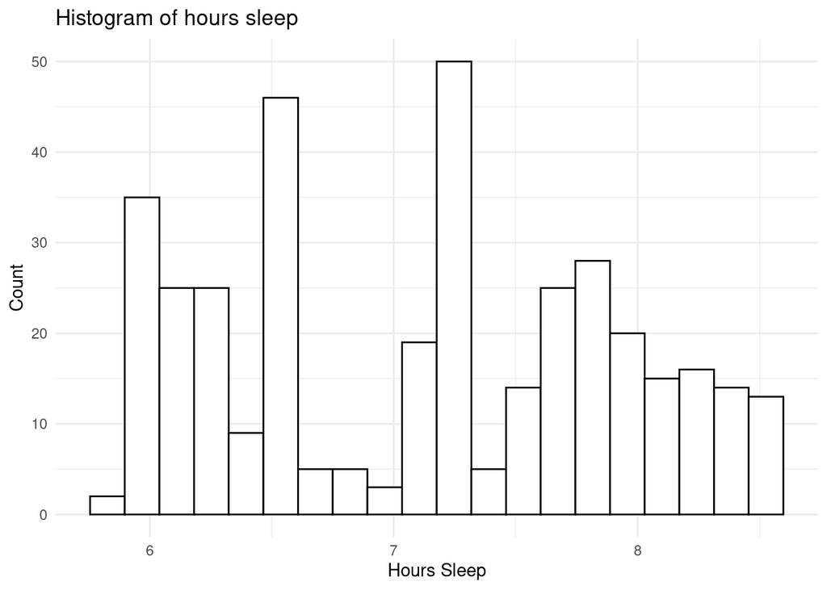

```r
library(ggplot2)
ggplot(data, aes(x=SH)) + geom_histogram(bins = 20,color="black",fill="white") +
  labs(title = "Histogram of hours sleep",
       x = "Hours Sleep",
       y = "Count") +
  theme_minimal()
```

Mirant el histograma la distribucio no sembla normal i encara que el valor mes comú esta prop del 7.5 sent mes o menys 7.3 i tenim valors al dos costats d’aquest i sembla que tenim una mica més en els valors més petits per tant sembla que la mitjana estara per sota, pero no ho podem asegurar fins fer el test estadistic

### 1.2 PR2: Existeixen diferències en la qualitat del son entre gèneres?

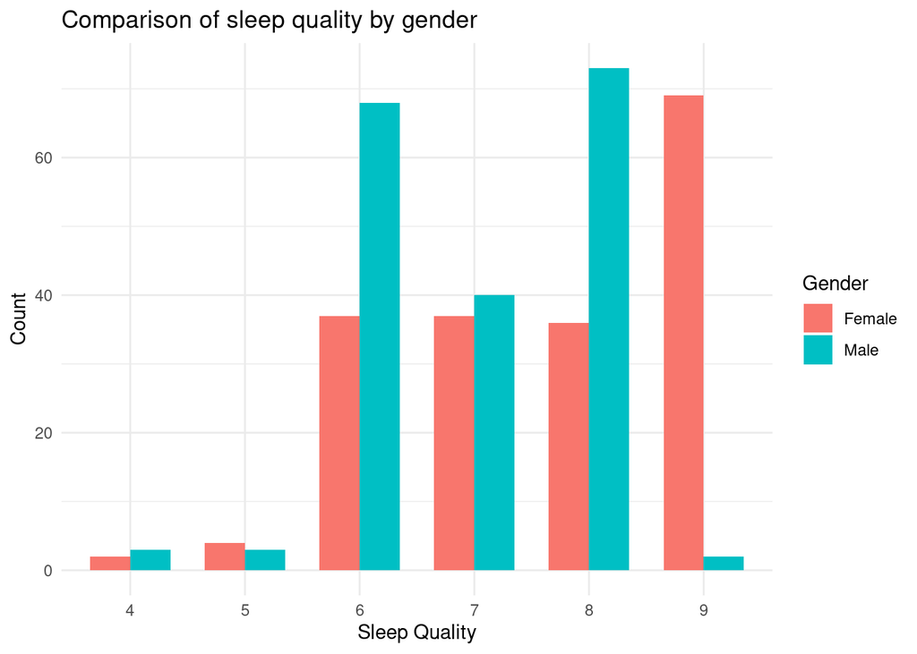

```r
library(ggplot2)
ggplot(data, aes(x=factor(SQ), fill=Gender)) +
  geom_bar(stat="count", width=0.7, position=position_dodge()) +
  labs(title = "Comparison of sleep quality by gender",
       x = "Sleep Quality",
       y = "Count") +
  theme_minimal()
```

Sembla que les dones tenen una qualitat del son superior ja que tenen més valors més alts

### 1.3 PR3: La proporció de persones amb trastorn del son és més gran en les persones amb nivells alts d’estrès en comparació amb les que presenten nivells baixos d’estrès?

Farem una taula de contingència on anotarem el nombre de casos observats per a cada combinació de les dues variables

```r
stres <- data$Stress>6
SD <- data$SD=="Insomnia"| data$SD=="Sleep Apnea"

result <- table(stres, SD)

# Print the result
print(result)
```

```
##        SD
## stres   FALSE TRUE
##   FALSE   183   71
##   TRUE     36   84
```

### 1.4 PR4: Hi ha una relació significativa entre la categoria de BMI (body mass index) i la presència de trastorns del son?

Farem una taula de contingència on anotarem el nombre de casos observats per a cada combinació de les dues variables.

```r
BMI <- data$BMI
SD <- data$SD

result <- table(BMI, SD)

# Print the result
print(result)
```

```
##             SD
## BMI          Insomnia None Sleep Apnea
##   Normal            9  200           7
##   Obese             4    0           6
##   Overweight       64   19          65
```

Sembla que si que hi ha una dependència ja que els que estan a un BMI “Normal” tenen molt menys trastorns del son i per exemple la categoria “Obese” no te ningú sense trastorns del son.

## 2 Mitjana d’hores de son (PR1)

En aquesta secció volem respondre la pregunta de recerca:

*PR1: La mitjana d’hores de son de la població és significativament inferior a 7.5 hores diàries?*

Per a donar-hi resposta, seguiu els passos que s’indiquen a continuació

### 2.1 Hipòtesis

$$H_0: \mu = 7.5 \newline H_1: \mu
<7.5$$

Per rebutjar la hipòtesis nul·la, caldrà observar evidència suficient que sigui notablement inferior que el valor de 7.5 hores.

### 2.2 Elecció del test

El que volem es un test sobre la mitjana amb variància desconeguda unilateral. Ja que nomes ens interessa saber si es significativament més baixa i la variància es desconeguda.

### 2.3 Test R

```r
t.test( data$SH, alternative="less", mu=7.5)
```

```
##
##  One Sample t-test
##
## data:  data$SH
## t = -8.9329, df = 373, p-value < 2.2e-16
## alternative hypothesis: true mean is less than 7.5
## 95 percent confidence interval:
##     -Inf 7.20024
## sample estimates:
## mean of x
##   7.13238
```

### 2.4 Desenvolupament

```r
my.ttest.L <- function(x, mu, alfa){
  mean <- mean(x)
  sd <- sd( x )
  n <- length( x )
  #Estadístic de contrast
  tobs <- (mean-mu)/(sd/sqrt(n))
  #Regió d’acceptació
  tcrit.L <- qt( alfa, df=n-1)
  #Càlcul del valor p
  pvalue <- pt( tobs, lower.tail=TRUE, df=n-1 )
  return ( data.frame( L=tcrit.L, U="INF", tobs, pvalue ) )
}
```

### 2.5 Resultats

```r
mu <- 7.5
alfa <- 0.05
my.ttest.L( data$SH, mu, alfa )
```

```
##           L   U      tobs       pvalue
## 1 -1.648949 INF -8.932869 9.645142e-18
```

### 2.6 Resposta a la pregunta d’investigació

Segons els dos tests la hipòtesis es falsa i la mitjana es menor de 7.5 amb un 95% de confiança en concret veiem que el p-value en els dos tests es menor que $10^{-15}$ per tant clarament la mitjana no és 7.5

## 3 Diferències en la qualitat del son segons gènere (PR2)

En aquesta secció volem respondre la pregunta de recerca:

*PR2: Existeixen diferències en la qualitat del son entre gèneres?*

### 3.1 Hipòtesis

$$H_0: \mu_1 = \mu_2 \newline
H_1: \mu_1 \ne \mu_2$$

Per rebutjar la hipòtesis nul·la, caldrà observar evidència suficient que les dos mitjanes siguin diferents.

### 3.2 Elecció del test

El primer que farem sera un test per mirar si les variàncies son iguals (test d’homoscedasticitat), ja que son desconegudes. En cas que les variàncies siguin iguals farem un test per mirar si les mitjanes son iguals suposant que les variàncies son iguals o diferents, depenent del resultat anterior.

### 3.3 Test R

```r
H <- data$SQ[ data$Gender=="Male" ]
D <- data$SQ[ data$Gender=="Female" ]
var.test(H, D)
```

```
##
##  F test to compare two variances
##
## data:  H and D
## F = 0.61023, num df = 188, denom df = 184, p-value = 0.0008081
## alternative hypothesis: true ratio of variances is not equal to 1
## 95 percent confidence interval:
##  0.4572736 0.8139732
## sample estimates:
## ratio of variances
##           0.610227
```

```r
t.test(H,D,alternative="two.sided", var.equal=FALSE)
```

```
##
##  Welch Two Sample t-test
##
## data:  H and D
## t = -5.8593, df = 347.96, p-value = 1.078e-08
## alternative hypothesis: true difference in means is not equal to 0
## 95 percent confidence interval:
##  -0.9304432 -0.4627786
## sample estimates:
## mean of x mean of y
##  6.968254  7.664865
```

### 3.4 Desenvolupament

```r
alfa <- 0.05
H <- data$SQ[ data$Gender=="Male" ]
D <- data$SQ[ data$Gender=="Female" ]
mean1 <- mean(H) ; n1 <- length(H) ; s1 <- sd( H )
mean2 <- mean(D) ; n2 <- length(D) ; s2 <- sd( D )

c(mean1, mean2, s1, s2, n1, n2 )
```

```
## [1]   6.9682540   7.6648649   0.9994933   1.2794819 189.0000000 185.0000000
```

```r
fobs<-s1^2 / s2^2
fcritL <- qf( alfa/2, df1=n1-1, df2=n2-2 )
fcritU <- qf( 1- alfa/2, df1=n1-1, df2=n2-2)
pvalue <- min(pf( fobs, df1=n1-1, df2=n2-2, lower.tail=FALSE ), pf( fobs, df1=n1-1, df2=n2-2))*2
c( fobs, fcritL, fcritU, pvalue)
```

```
## [1] 0.6102270332 0.7494328180 1.3351018288 0.0008191195
```

```r
my.ttest <- function(x, y, alfa){
  mean1 <- mean(x)
  mean2 <- mean(y)
  sd1 <- sd( x )
  sd2 <- sd( y )
  n1 <- length( x )
  sd2 <- sd( y )
  s <- sqrt(((n1-1)*s1**2+(n2-1)*s2**2)/(n1+n2-2))
  gll <- ((s1**2)/n1+(s2**2)/n2)/((((s1**2)/n1)**2)/(n1-1)+(((s2**2)/n2)**2)/(n2-1))
  #Estadístic de contrast
  tobs <- (mean1-mean2) / (sqrt((s1**2)/n1 + (s2**2)/n2))
  #Regió d’acceptació
  tcritL <- qt( alfa/2, gll)
  tcritU <- qt( 1-alfa/2, gll)
  pvalue <-pt( abs(tobs), df=gll, lower.tail=FALSE)*2
  return ( data.frame( L=tcritL, U=tcritU, tobs, pvalue) )
}
```

### 3.5 Resultats

```r
H <- data$SQ[ data$Gender=="Male" ]
D <- data$SQ[ data$Gender=="Female" ]
alfa <- 0.05
my.ttest( H, D, alfa )
```

```
##          L       U      tobs       pvalue
## 1 -1.96006 1.96006 -5.859318 4.706875e-09
```

### 3.6 Resposta a la pregunta d’investigació

Veiem primer que el p-valor de el test d’igualtat de variança es molt petit per tant les variàncies no son iguals i despres mirant el test per mirar si les mitjanes no son iguals assumint que les variàncies son diferents el valor del p es menor que el nivell de significança per tant podem rebutjar la hipòtesi nul·la d’igualtat entre mitjanes de qualitat del son entre homes i dones.

## 4 L’estrès influeix en el trastorns del son? (PR3)

En aquesta secció volem respondre la pregunta de recerca:

*PR3: La proporció de persones amb trastorn del son és més gran en les persones amb nivells alts d’estrès en comparació amb les que presenten nivells baixos d’estrès?*

### 4.1 Hipòtesis

$$H_0: p_1 = p_2 \newline H_1: p_1
\ne p_2$$

Per rebutjar la hipòtesis nul·la, caldrà observar evidència suficient que la proporció de persones amb trastorns del son es diferent si el nivell d’estres es alt o no.

### 4.2 Elecció del test

Farem un test sobre la diferència de dues proporcions, amb mostres grans

### 4.3 Test R

```r
ts <- data[ which(data$SD=="Insomnia"| data$SD=="Sleep Apnea"), ]
sa <- data[ data$SD=="None", ]
n1 <- length( ts$Stress )
n2 <- length( sa$Stress )
p1 <- sum(ts$Stress>6)/n1; p1
```

```
## [1] 0.5419355
```

```r
p2 <- sum(sa$Stress>6)/n2; p2
```

```
## [1] 0.1643836
```

```r
success<-c( p1*n1, p2*n2)
nn<-c(n1,n2)
prop.test(success, nn, alternative="two.sided", correct=FALSE)
```

```
##
##  2-sample test for equality of proportions without continuity correction
##
## data:  success out of nn
## X-squared = 59.373, df = 1, p-value = 1.305e-14
## alternative hypothesis: two.sided
## 95 percent confidence interval:
##  0.2850221 0.4700817
## sample estimates:
##    prop 1    prop 2
## 0.5419355 0.1643836
```

### 4.4 Desenvolupament

```r
my.ttestprop <- function(x1, x2, alfa){
  n1 <- length( x1$Stress )
  n2 <- length( x2$Stress )
  p1 <- sum(x1$Stress>6)/n1
  p2 <- sum(x2$Stress>6)/n2
  p<-(n1*p1 + n2*p2) / (n1+n2)
  #Estadístic de contrast
  tobs <- (p1-p2)/( sqrt(p*(1-p)*(1/n1+1/n2)) )
  #Regió d’acceptació
  tcrit <- qnorm(alfa, lower.tail=FALSE)
  pvalue <- pnorm(tobs, lower.tail=FALSE)


  return ( data.frame( ZC=tcrit, tobs, pvalue) )
}
```

### 4.5 Resultats

```r
ts <- data[ which(data$SD=="Insomnia"| data$SD=="Sleep Apnea"), ]
sa <- data[ data$SD=="None", ]
alfa <- 0.05
my.ttestprop( ts, sa, alfa )
```

```
##         ZC    tobs       pvalue
## 1 1.644854 7.70536 6.523767e-15
```

### 4.6 Resposta a la pregunta d’investigació

Amb un nivell de confiança molt alt es pot rebutjar l’hipòtesis nul·la ja que el p valor es 6.523767e-15 per tant podem concloure que la proporció de població que te trastorns del son es més alta en gent amb estres.

## 5 BMI i trasntorns del son (PR4)

En aquesta secció volem respondre la pregunta de recerca:

*R4: Hi ha una relació significativa entre la categoria de BMI i la presència de trastorns del son?*

### 5.1 Hipòtesis

- $H_0:$ la categoria de BMI i la presencia de trastorns del son són variables independents.
- $H_1:$ hi ha una relació entre les variables de categoria de BMI i presencia de trastorns del son.

### 5.2 Elecció del test

Farem un test de dependència de dues variables

### 5.3 Test R

```r
BMI <- data$BMI
SD <- data$SD

result <- table(BMI, SD)
chisq.test(result, correct=FALSE)
```

```
##
##  Pearson's Chi-squared test
##
## data:  result
## X-squared = 245.67, df = 4, p-value < 2.2e-16
```

### 5.4 Desenvolupament

```r
my.ttestinde <- function(x1, x2, alfa){
  qobs <- 0
  table <- addmargins(table(x1, x2))
  n1 <- length(unique(x1))
  n2 <- length(unique(x2))
  #Estadístic de contrast
  for(i in 1:n1){
    for (j in 1:n2) {
      e <- table[i,n1+1]*table[n2+1,j]/table[n1+1,n2+1]
      qobs <- qobs+ (((table[i,j] - e)**2)/e)
    }
  }
  #Regió d’acceptació
  tcrit <- qchisq(alfa, df=4, lower.tail = FALSE)
  pvalue <- pchisq(qobs, df=4, lower.tail = FALSE)


  return ( data.frame( ZC=tcrit, qobs, pvalue) )
}
```

### 5.5 Resultats

```r
BMI <- data$BMI
SD <- data$SD
alfa <- 0.05
my.ttestinde( BMI, SD, alfa )
```

```
##         ZC     qobs       pvalue
## 1 9.487729 245.6653 5.588351e-52
```

### 5.6 Resposta a la pregunta d’investigació

Amb un nivell de confiança molt alt es pot rebutjar l’hipòtesis nul·la ja que el p valor es molt baix per tant podem concloure que les dos variables no son independents i estan fortament correlacionades.

## 6 Taula resum

[output not shown]

## 7 Resum executiu

Les conclusions que podem treure d’aquest resultat és que la mitjana d’hores de son en aquest grup és menor que 7 hores i mitja, cosa esperable tenint en compte que part del grup d’estudi pateix trastorns del son. També podem concloure que els dos gèneres tenen mitjanes diferents de qualitat del son. Addicionalment, veiem que una població amb estrès alt té una proporció més alta de trastorns del son i per últim veiem que el BMI està correlacionat amb la presència de trastorns del son, cosa que té sentit, ja que un dels factors de risc de les apnees de son és el sobrepès.